# 03_Multivariate

Marc Koh

2025-10-14

# Multivariate Analyses

This Markdown will give you a quick tutorial to follow for multivariate analyses.

# Introduction

So far, you have done some basic data analyses in the form of:

- t-tests
- ANOVAs
- Linear Models
- Generalised Linear Models

These are known as *univariate* analyses, where you have one response variable and one or several independent variables:

$$Y \sim X_{1} + X_{2} * X_{3}+ \cdots+
X_{n}$$

As you probably know by now, this is usually done to address hypotheses or research questions where you are looking at how a specific singular variable changes with the rest of your predictors.

Ecological data is a complex thing, where in certain scenarios, you want to tease out more information, or look at slightly more complex relationships.

For example, using something like a Simpsons Diversity Index is a pretty common way to compare species diversities between locations.

Although a totally acceptable way to assess diversity, there are better alternatives to assess this now that the average computer has much more more processing power.

## What Is Multivariate Statistics?

If univariate statistics has 1 response variable (uni = 1, duh), multivariate statistics has **multiple** response variables:

$$Y_{1} + Y_{2} + Y_{3}+ \cdots+ Y_{n}\sim
X_{1} + X_{2} * X_{3}$$
In the example of species diversity, $Y_{n}$ represents species that were recorded in your dataset, where you are looking at how certain environmental variables could affect changes in species abundance:

$$Sp_{1}+Sp_{2}+Sp_{3}+....Sp_{n} \sim
Site + Salinity +Temperature$$

## Where do I Begin? (Workflow)

If you’re not familiar with data analysis, my suggested general workflow is that you:

1. Clean and wrangle your data
2. Visualise your data
3. Conduct analyses
4. Interpret your analyses

This workflow is what I generally apply for most data analyses.

The next section will give you an example of this using dummy foraminifera data collected on Heron Island.

# Multivariate Analyses Example

This example will run through the data analysis from importing, cleaning and wrangling, visualisation.

More specifically, we will be doing a **Non-Metric Multidimensional Scaling (NMDS)** and a **Permutational Multivariate Analysis of Variance (PERMANOVA)**.

If you have done a Principle Component Analysis (PCA) before, an NMDS is a similar technique that uses distances from a dissimilarity calculation instead of eigenvalues which PCAs use.

The research question that is trying to be answered here is:

**What is the distribution of Forams on Heron Reef?**

Specifically, this group tried to look for differences in 3 locations, the Reef Crest, Lagoon, and Flat, and at several different sediment size classes to see if Forams had a settlement preferences in terms of location or sediment size.

For the sake of this example, we will just look at how

location affects species abundance

Let’s begin…

## Packages

Packages you will specifically need to follow along with this are:

```r
library(readxl) # for reading excel into R
library(tidyverse) # for wrangling and cleaning
library(vegan) # package designed specifically for community ecology
library(ggordiplots) # ggplot version for multivariate visualisation
library(MetBrewer) # MET colour palette
library(pairwiseAdonis) # for pairwise testing
```

## Load Data In

Let’s load this dummy dataset in to see what it looks like:

```r
foram <- read_xlsx("Dummy_foram.xlsx",
                   sheet = 1) # you can choose which sheet to import
```

Have a look at what it looks like:

```r
head(foram)
```

```
## # A tibble: 6 × 14
##   Location `Sample number` `Sediment Size` Latitude Longitude `No Forams`  Star
##   <chr>              <dbl>           <dbl>    <dbl>     <dbl>       <dbl> <dbl>
## 1 Crest                  1             125    -23.5      152.         196    NA
## 2 Crest                  1             250    -23.5      152.         191     4
## 3 Crest                  1             500    -23.5      152.         167    29
## 4 Crest                  2             125    -23.5      152.         197    NA
## 5 Crest                  2             250    -23.5      152.         197     3
## 6 Crest                  2             500    -23.5      152.         153    47
## # ℹ 7 more variables: `smooth spiral` <dbl>, `rough spiral` <dbl>,
## #   `rice-grain` <dbl>, `rounded flat` <dbl>, bell <dbl>, bumpy <dbl>,
## #   round <dbl>
```

Some things to note here:

1. The first 6 columns are abiotic variables, everything after is the abundance of **morphospecies**
2. Some of these columns are categorical variables, which we will have to make sure we tell R later.
3. There are a lot of NAs in the dataset, which probably should have been filled with 0s.

## Data Wrangling

Let’s get rid of the NAs and make some of the environmental variables categoridcal:

```r
foram <- foram %>% replace(is.na(.), 0) # replace NAs with 0s

foram <- foram %>% mutate(Location = as_factor(Location),
                          `Sample number` = as_factor(`Sample number`),
                          `Sediment Size` = as_factor(`Sediment Size`))

str(foram) # check structure
```

```
## tibble [45 × 14] (S3: tbl_df/tbl/data.frame)
##  $ Location     : Factor w/ 3 levels "Crest","Lagoon",..: 1 1 1 1 1 1 1 1 1 1 ...
##  $ Sample number: Factor w/ 5 levels "1","2","3","4",..: 1 1 1 2 2 2 3 3 3 4 ...
##  $ Sediment Size: Factor w/ 3 levels "125","250","500": 1 2 3 1 2 3 1 2 3 1 ...
##  $ Latitude     : num [1:45] -23.5 -23.5 -23.5 -23.5 -23.5 ...
##  $ Longitude    : num [1:45] 152 152 152 152 152 ...
##  $ No Forams    : num [1:45] 196 191 167 197 197 153 195 190 166 192 ...
##  $ Star         : num [1:45] 0 4 29 0 3 47 0 2 33 1 ...
##  $ smooth spiral: num [1:45] 1 2 0 0 0 0 0 4 0 0 ...
##  $ rough spiral : num [1:45] 0 0 1 0 0 0 0 0 0 0 ...
##  $ rice-grain   : num [1:45] 0 2 0 3 0 0 4 1 0 7 ...
##  $ rounded flat : num [1:45] 1 1 2 0 0 0 0 3 0 0 ...
##  $ bell         : num [1:45] 1 0 1 0 0 0 1 0 0 0 ...
##  $ bumpy        : num [1:45] 1 0 0 0 0 0 0 0 1 0 ...
##  $ round        : num [1:45] 0 0 0 0 0 0 0 0 0 0 ...
```

All sorted!

## Visualisation (NMDS)

Recall the sample equation above:

$$Sp_{1}+Sp_{2}+Sp_{3}+....Sp_{n} \sim
Site + Salinity +Temperature$$

If we re-purpose it for our data and research question, it would look something like this:
$$Sp_{1}+Sp_{2}+Sp_{3}+....Sp_{n} \sim
Location$$

However, since we have multiple rows of data, a more accurate way to visualise this is using a table, or matrix:

$$\begin{equation}
\begin{pmatrix}
Sp_{1} & Sp_{2} & \cdots & Sp_{n} \\
Sp_{1} & Sp_{2} & \cdots & Sp_{n} \\
\vdots & \vdots & \ddots & \vdots \\
Sp_{1} & Sp_{2} & \cdots & Sp_{n}
\end{pmatrix}
\sim Location
\end{equation}$$

Where, each observation in the matrix is an abundance count per species per collection.

Therefore, to get this matrix, we need to pull out the species abundance data into what we call a **community matrix**

### Create Community Matrix

```r
for_com <- foram %>%
  select(`No Forams`:ncol(foram)) #

str(for_com)
```

```
## tibble [45 × 9] (S3: tbl_df/tbl/data.frame)
##  $ No Forams    : num [1:45] 196 191 167 197 197 153 195 190 166 192 ...
##  $ Star         : num [1:45] 0 4 29 0 3 47 0 2 33 1 ...
##  $ smooth spiral: num [1:45] 1 2 0 0 0 0 0 4 0 0 ...
##  $ rough spiral : num [1:45] 0 0 1 0 0 0 0 0 0 0 ...
##  $ rice-grain   : num [1:45] 0 2 0 3 0 0 4 1 0 7 ...
##  $ rounded flat : num [1:45] 1 1 2 0 0 0 0 3 0 0 ...
##  $ bell         : num [1:45] 1 0 1 0 0 0 1 0 0 0 ...
##  $ bumpy        : num [1:45] 1 0 0 0 0 0 0 0 1 0 ...
##  $ round        : num [1:45] 0 0 0 0 0 0 0 0 0 0 ...
```

Next, we have to check the range of values to make sure that we don’t an over representation of species (e.g. a data point where Sp1 is 10000000 while everything is between 1 and 10)

```r
range(for_com) # Check range
```

```
## [1]   0 200
```

**It is important that you check the difference in orders of magnitude here because an over-representation of a species may mask any differences between data points caused by under-represented species.**

Although this is not too bad, I will apply a square root to the community matrix to show you how to reduce the orders of magnitude:

```r
for_com <- sqrt(for_com)
range(for_com) # check again
```

```
## [1]  0.00000 14.14214
```

Depending on the orders of magnitude of difference between your abundances, you may end up having to apply more aggressive transformations like:

1. Log-transformation `log()`
2. Fourth-root transformations `sqrt(sqrt())`

**Warning!** There is a trade off between over-transforming your data and something we call stress. I will explain this in a bit…

### NMDS

An NMDS is a visualisation technique used to visualise the community matrix.

In simpler terms, a matrix allows for us to look at data from different angles to find similarities between each data point. This means that there are several different dimensions (or angles) in which we can interpret the matrix. The NMDS uses what is called distance-based ordination to find the best 2 to 3 dimensions in which the data can be best visualised.

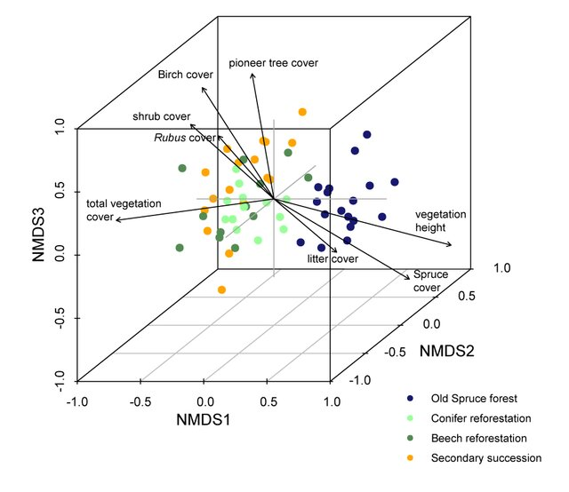

An example of an NMDS plot from Kamp et al. 2020 with 3 Dimensions

Each row of data is represented as one point in these plots.

#### Stress

One of the things you will have to report is stress.

Stress is a measure of goodness-of-fit of the matrix to a 2 dimensional or 3 dimensional space. According to [original paper proposing NMDS](https://link.springer.com/article/10.1007/BF02289565) by Kruskal, the ideal level of stress should be **< 0.1** and **anything above 0.2 should be interpreted with caution**. A few reasons why your stress may be above 0.2 include:

- Extremely large datasets
- Over-transforming your data

Although 0.2 is what most people agree on, there may be times in future it is impossible for you to reduce it below 0.2. There are other techniques around this including producing a histogram of Permutation Based Ordination of your data to show that it already is the best case scenario.

Let’s try to get an NMDS from the foram data:

```r
for_com.nmds <- metaMDS(for_com,
                        autotransform = F,
                        distance = "bray") # Bray Curtis Dissmiliarity Index
```

```
## *** Best solution was not repeated -- monoMDS stopping criteria:
##      1: no. of iterations >= maxit
##     18: stress ratio > sratmax
##      1: scale factor of the gradient < sfgrmin
```

```r
signif(for_com.nmds$stress, digits = 4) # find stress
```

```
## [1] 0.1269
```

We have a stress value of $0.1269$, which is not too bad!

Now, lets try to visualise this in a 2D space:

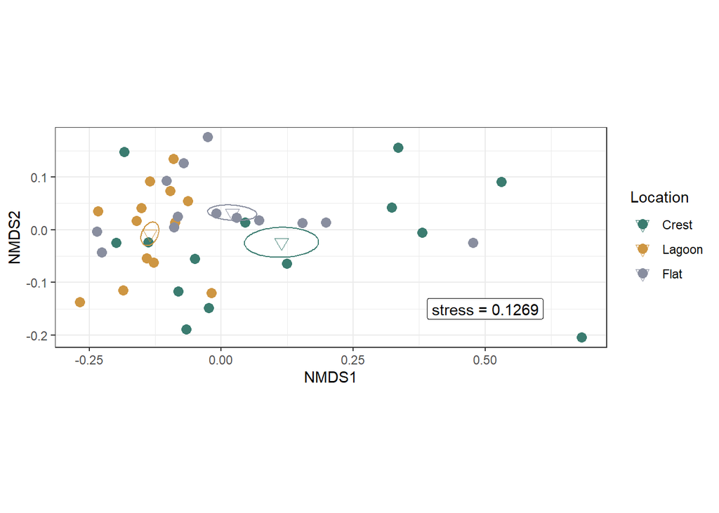

```r
theme_set(theme_bw())

for_com.loc.plot <- gg_ordiplot(for_com.nmds,
                                 groups = foram$Location,
                                 ellipse = T,
                                 kind = "se", # show ellipses for standard error of mean
                                 plot = F)

for_com.loc.plot <- for_com.loc.plot$plot+
  geom_point(data = for_com.loc.plot$df_mean.ord,
             aes(x = x, y = y,  colour = Group),
             shape = 25,
             size = 3)+
#  geom_text(data = for_com.loc.plot$df_mean.ord,
#            aes(x =x, y = y, label = Group),
#            size = 3)+
  scale_colour_manual("Location", # manual colour palette change
                      values = met.brewer("Kandinsky"),
                      breaks = c("Crest", "Lagoon", "Flat"))+
  annotate("label", x = 0.5, y = -0.15,
           label = bquote("stress = 0.1269")) # you may have to move this in your own plot

for_com.loc.plot
```

Well done, you’ve made your first NMDS!

You can make it better by adding Species Scores to this:

[output not shown]

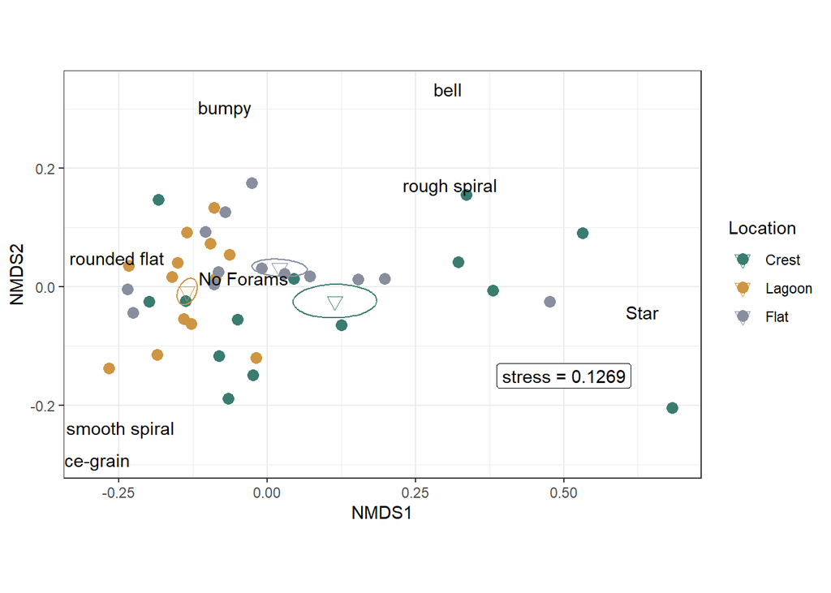

```r
data.scores <- as_tibble(scores(for_com.nmds$species))
species.scores <- as.data.frame(scores(for_com.nmds, "species"))
species.scores$species <- rownames(species.scores)
species.scores <- species.scores[1:8,] # remove round, too far away

for_com.loc.plot +
  geom_text(data = species.scores,
            aes(x = NMDS1,y = NMDS2,label = species),
            alpha=1) +  # add the species labels
  coord_equal()
```

What the Species Scores does is it imposes the species onto the NMDS plot, meaning that the closer a data point is to the species name, the higher the amount of that species in that sample.

## Statistical Analysis

Recall that an NMDS is not really an analysis, and more of a visualisation. Although the NMDS above shows you the potential differences between locations, you still haven’t really tested it with a statisical test yet.

This is where the PERMANOVA comes in.

A PERMANOVA is essentially an ANOVA with permutations for the multivariate data, meaning that is repeated several times based on the ordination (from mutliple dimensions) and the best result is presented. This is one in action:

```r
set.seed(6971)

for_permanova <- adonis2(for_com ~ Location,
                         data = foram)

for_permanova
```

```
## Permutation test for adonis under reduced model
## Terms added sequentially (first to last)
## Permutation: free
## Number of permutations: 999
##
## adonis2(formula = for_com ~ Location, data = foram)
##          Df SumOfSqs      R2      F Pr(>F)
## Location  2  0.16833 0.20416 5.3871  0.001 ***
## Residual 42  0.65619 0.79584
## Total    44  0.82452 1.00000
## ---
## Signif. codes:  0 '***' 0.001 '**' 0.01 '*' 0.05 '.' 0.1 ' ' 1
```

The PERMANOVA here essentially shows that about 20.4% of variation can of the mean species composition can be attributed to the variable of `Location`.

Remember that for an ANOVA, you will have to do a Tukey Test for Honest Significant Difference. PERMANOVAs are similiar, in that you can do a pairwise test to show this using the `pairwise.adnois` package:

```r
# For if you have a second level:
#foram_df <- as.data.frame(foram) %>%
#  rename(sed_size = `Sediment Size`)

for_pair <- pairwise.adonis2(for_com ~ Location,
                             #strata = 'sed_size', # second level
                             data = foram)

for_pair
```

```
## $parent_call
## [1] "for_com ~ Location , strata = Null , permutations 999"
##
## $Crest_vs_Lagoon
##          Df SumOfSqs      R2      F Pr(>F)
## Location  1  0.14657 0.23857 8.7728  0.001 ***
## Residual 28  0.46781 0.76143
## Total    29  0.61438 1.00000
## ---
## Signif. codes:  0 '***' 0.001 '**' 0.01 '*' 0.05 '.' 0.1 ' ' 1
##
## $Crest_vs_Flat
##          Df SumOfSqs      R2      F Pr(>F)
## Location  1  0.03359 0.05594 1.6593  0.178
## Residual 28  0.56689 0.94406
## Total    29  0.60049 1.00000
##
## $Lagoon_vs_Flat
##          Df SumOfSqs      R2      F Pr(>F)
## Location  1  0.07233 0.20666 7.2937  0.001 ***
## Residual 28  0.27768 0.79334
## Total    29  0.35002 1.00000
## ---
## Signif. codes:  0 '***' 0.001 '**' 0.01 '*' 0.05 '.' 0.1 ' ' 1
##
## attr(,"class")
## [1] "pwadstrata" "list"
```

What you are seeing here is essentially there is a real difference in species composition between the Flat and the Lagoon, as well as the Crest and the Lagoon, while there is no real difference between the Crest and Flat.

This means that the Lagoon has a unique composition of species compared to the other 2 locations!

**Warning!** Because this method is permutation based, the results may not always be the same every time you run it. This is why you set a seed using the `set.seed()` function so that your results can be replicated.